# Exercise 7 - Resampling Methods and Model Selection

Ken Benoit, Slava Mikhaylov, and Jack Blumenau

## Exercise 7.1

In the lab session for this topic (Sections 5.3.2 and 5.3.3 in James et al.), we saw that the `cv.glm()` function can be used in order to compute the LOOCV test error estimate. Alternatively, one could compute those quantities using just the `glm()` and `predict.glm()` functions, and a `for` loop. You will now take this approach in order to compute the LOOCV error for a simple logistic regression model on the `Weekly` data set. Recall that in the context of classification problems, the LOOCV error is given in Section 5.1.5 (5.4, page 184).

```r
data("Weekly", package = "ISLR")
```

1. Fit a logistic regression model that predicts `Direction` using `Lag1` and `Lag2`.

```r
fit1 <- glm(Direction ~ Lag1 + Lag2, data = Weekly, family = binomial)
```

2. Fit a logistic regression model that predicts `Direction` using `Lag1` and `Lag2` using *all but the first observation*.

```r
Weekly1 <- Weekly[-1,]
fit2 <- glm(Direction ~ Lag1 + Lag2, data = Weekly1, family = binomial)
```

3. Use the model from (b) to predict the direction of the first observation. You can do this by predicting that the first observation will go up if `P(Direction="Up"|Lag1, Lag2) > 0.5`. Was this observation correctly classified?

```r
predict.glm(fit2, Weekly[1,], type = "response") > 0.5
```

```
##    1
## TRUE
```

**The prediction for the first observation is “Up”. It is wrongly classified as the actual direction is “Down”.**

4. Write a `for` loop from i=1 to i=n, where n is the number of observations in the data set, that performs each of the following steps:

```
i. Fit a logistic regression model using all but the i-th observation to predict `Direction` using `Lag1` and `Lag2`.

ii. Compute the posterior probability of the market moving up for the i-th observation.

iii. Use the posterior probability for the i-th observation in order to predict whether or not the market moves up.

iv. Determine whether or not an error was made in predicting the direction for the i-th observation. If an error was made, then indicate this as a 1, and otherwise indicate it as a 0.
```

```r
library(plyr, quietly = TRUE)

false_up <- rep(0, dim(Weekly)[1])

for (i in 1:dim(Weekly)[1]) {
  fit3 <- glm(Direction ~ Lag1 + Lag2, data = Weekly[-i,], family = binomial)
  predict_up <- predict.glm(fit3, Weekly[i,], type = "response") > 0.5
  correct_up <- Weekly[i,]$Direction == "Up"

  if (predict_up != correct_up)
    false_up[i] <- 1
}
false_up
```

```
##    [1] 1 1 0 1 0 1 0 0 0 1 1 0 1 0 1 0 1 0 1 0 0 0 1 1 1 1 1 1 0 1 1 1 1 0 1 0 0
##   [38] 0 1 0 1 0 0 1 0 1 1 1 0 1 0 0 0 1 0 0 1 1 0 0 0 0 1 0 1 1 0 0 1 0 1 1 0 0
##   [75] 0 1 0 1 1 0 0 1 1 0 1 1 0 0 1 0 0 1 1 1 0 0 0 0 0 1 0 1 1 0 0 1 0 1 0 0 1
##  [112] 1 0 0 1 0 0 1 0 0 1 1 1 1 0 0 0 1 0 1 0 1 1 0 0 0 1 1 1 0 0 0 1 0 0 0 0 0
##  [149] 0 1 1 1 0 1 0 0 1 1 0 1 0 0 1 1 0 0 1 0 0 1 0 0 1 1 1 0 1 0 1 0 0 0 0 0 0
##  [186] 0 0 1 1 0 1 0 1 0 1 0 1 0 0 1 0 0 1 0 0 1 0 1 0 1 1 1 0 0 1 1 0 1 0 0 1 1
##  [223] 0 0 0 1 1 1 0 1 0 1 0 1 0 0 0 1 1 0 1 0 1 0 1 0 1 0 1 1 0 1 0 0 1 0 0 1 0
##  [260] 0 0 0 0 1 0 0 0 1 0 0 1 0 0 0 1 0 0 1 0 0 1 0 0 1 0 1 1 0 0 0 0 0 1 0 1 0
##  [297] 0 1 0 0 0 1 0 0 1 1 0 0 1 0 0 0 0 1 0 1 1 0 0 1 0 1 0 1 1 0 0 0 1 0 1 0 0
##  [334] 1 1 1 1 0 1 0 0 1 0 0 0 1 0 1 0 1 0 0 0 0 0 1 1 0 0 1 0 0 1 0 0 0 1 1 0 1
##  [371] 1 1 1 1 0 0 0 1 0 0 0 0 0 0 1 0 1 1 0 0 1 1 0 0 0 0 0 1 0 0 1 1 1 0 1 0 1
##  [408] 0 1 1 1 0 1 0 0 0 0 0 0 0 0 0 0 1 0 1 0 1 0 1 0 0 1 0 1 0 0 0 0 0 1 1 1 1
##  [445] 0 1 1 0 1 0 1 1 0 1 0 0 1 0 0 1 1 0 0 0 0 1 1 0 0 1 0 1 0 0 0 1 0 0 1 0 0
##  [482] 0 1 1 1 0 1 0 0 0 1 0 1 1 1 0 0 0 0 1 1 1 0 1 1 0 1 0 0 0 1 0 1 0 0 0 1 0
##  [519] 1 1 0 0 1 1 0 0 0 1 1 0 1 0 1 1 1 1 1 0 0 0 1 0 0 0 1 1 0 1 0 0 0 1 1 1 1
##  [556] 1 1 0 1 0 1 0 0 1 0 0 1 1 1 0 0 0 1 1 1 1 1 1 1 1 1 1 0 1 0 0 1 0 0 1 0 1
##  [593] 0 0 1 0 0 1 0 1 1 0 1 1 1 0 1 0 1 0 1 0 0 0 1 0 1 0 1 0 1 1 0 1 1 0 1 0 1
##  [630] 0 1 1 1 1 0 1 1 0 0 0 1 1 1 1 0 1 1 1 0 1 0 0 0 1 1 1 1 1 1 0 1 0 0 1 0 0
##  [667] 0 1 1 0 1 0 1 1 1 1 0 0 0 1 1 0 0 0 0 0 0 0 0 0 0 1 0 0 0 0 1 0 0 1 0 1 1
##  [704] 0 0 0 0 1 0 1 0 1 0 1 0 0 1 1 0 0 0 0 0 0 0 0 0 1 0 0 1 0 0 1 1 1 0 1 1 0
##  [741] 1 1 1 1 0 0 0 1 1 1 1 1 1 0 1 0 0 0 0 0 0 1 0 1 1 1 0 0 0 1 0 0 1 0 0 0 1
##  [778] 1 1 0 0 0 1 0 0 1 1 1 0 0 1 0 1 0 1 0 0 1 0 0 1 0 0 0 0 0 1 0 1 1 0 0 1 1
##  [815] 0 1 1 1 0 0 0 0 0 1 1 0 0 1 0 0 1 0 1 0 0 0 1 1 0 1 1 0 1 0 1 0 1 1 0 0 1
##  [852] 1 1 0 1 1 0 0 0 1 0 1 0 1 0 1 0 0 0 0 0 1 0 0 1 1 0 0 1 0 1 0 1 1 0 1 0 1
##  [889] 1 0 0 0 1 0 0 0 0 0 0 0 1 0 1 0 1 0 0 0 1 1 1 1 1 0 1 1 0 0 0 0 0 1 0 0 1
##  [926] 0 0 0 0 1 0 1 1 1 0 0 1 1 0 1 1 1 1 0 1 0 1 0 1 0 1 0 1 0 0 1 1 1 1 1 0 1
##  [963] 0 0 0 1 1 1 0 1 1 1 1 0 0 0 0 1 1 0 0 0 0 1 0 0 1 1 1 0 0 1 1 1 0 1 0 0 0
## [1000] 0 1 0 0 1 0 1 0 0 1 1 1 1 0 1 0 0 1 0 0 1 0 0 1 1 0 1 1 1 0 1 1 0 0 0 1 0
## [1037] 1 0 1 1 1 1 0 0 1 0 0 0 0 0 0 1 0 1 1 0 0 0 0 0 1 1 1 0 0 0 1 0 1 1 1 0 0
## [1074] 0 0 1 0 0 0 0 0 1 0 1 0 0 0 0 0
```

```r
sum(false_up)
```

```
## [1] 490
```

**490 false prediction is made.**

5. Take the average of the n numbers obtained in (d)iv in order to obtain the LOOCV estimate for the test error. Comment on the results.

```r
mean(false_up)
```

```
## [1] 0.4499541
```

## Exercise 7.2

In this exercise, we will predict the number of applications received using the other variables in the `College` data set.

```r
data("College", package = "ISLR")
```

1. Split the data set into a training set and a test set.

```r
library(caTools, quietly = TRUE)

set.seed(1234)
sample = sample.split(College, SplitRatio = 0.5)
College_Training <- subset(College, sample == TRUE)
College_Test <- subset(College, sample == FALSE)
```

2. Fit a linear model using least squares on the training set, and report the test error obtained.

```r
#install.packages("olsrr")
library(olsrr)
fit4 <- lm(Apps ~ ., data = College_Training)
ols_regress(fit4)
```

```
##                            Model Summary
## -------------------------------------------------------------------
## R                       0.955       RMSE                  1078.030
## R-Squared               0.913       Coef. Var               35.413
## Adj. R-Squared          0.909       MSE                1162148.823
## Pred R-Squared          0.897       MAE                    637.529
## -------------------------------------------------------------------
##  RMSE: Root Mean Square Error
##  MSE: Mean Square Error
##  MAE: Mean Absolute Error
##
##                                     ANOVA
## ------------------------------------------------------------------------------
##                       Sum of
##                      Squares         DF      Mean Square       F         Sig.
## ------------------------------------------------------------------------------
## Regression    4496073028.122         17    264474884.007    227.574    0.0000
## Residual       429995064.362        370      1162148.823
## Total         4926068092.485        387
## ------------------------------------------------------------------------------
##
##                                       Parameter Estimates
## -----------------------------------------------------------------------------------------------
##       model        Beta    Std. Error    Std. Beta      t        Sig         lower       upper
## -----------------------------------------------------------------------------------------------
## (Intercept)    -380.263       585.492                 -0.649    0.516    -1531.572     771.047
##  PrivateYes    -920.592       218.012       -0.117    -4.223    0.000    -1349.291    -491.893
##      Accept       1.209         0.081        0.786    14.921    0.000        1.050       1.368
##      Enroll      -0.055         0.300       -0.015    -0.184    0.854       -0.645       0.535
##   Top10perc      51.466         7.794        0.279     6.604    0.000       36.141      66.791
##   Top25perc     -18.937         6.460       -0.108    -2.932    0.004      -31.639      -6.235
## F.Undergrad       0.045         0.056        0.061     0.807    0.420       -0.065       0.156
## P.Undergrad      -0.045         0.061       -0.016    -0.742    0.459       -0.165       0.075
##    Outstate      -0.027         0.029       -0.032    -0.935    0.350       -0.085       0.030
##  Room.Board       0.181         0.071        0.057     2.569    0.011        0.043       0.320
##       Books      -0.054         0.357       -0.002    -0.150    0.881       -0.757       0.649
##    Personal      -0.015         0.087       -0.003    -0.168    0.867       -0.185       0.156
##         PhD      -8.920         7.410       -0.040    -1.204    0.229      -23.491       5.651
##    Terminal      -7.674         8.077       -0.032    -0.950    0.343      -23.557       8.209
##   S.F.Ratio      30.619        21.282        0.033     1.439    0.151      -11.229      72.467
## perc.alumni      -8.274         6.288       -0.030    -1.316    0.189      -20.640       4.091
##      Expend       0.098         0.019        0.150     5.196    0.000        0.061       0.135
##   Grad.Rate      11.733         4.253        0.058     2.759    0.006        3.370      20.095
## -----------------------------------------------------------------------------------------------
```

```r
Predict <- predict(fit4, College_Test)
mean((College_Test[,"Apps"] - Predict)^2)
```

```
## [1] 1361920
```

**Test Error obtained is 1361920.**

3. Fit a ridge regression model on the training set, with $\lambda$ chosen by cross-validation. Report the test error obtained.

```r
#install.packages("glmnet")
library(glmnet)
```

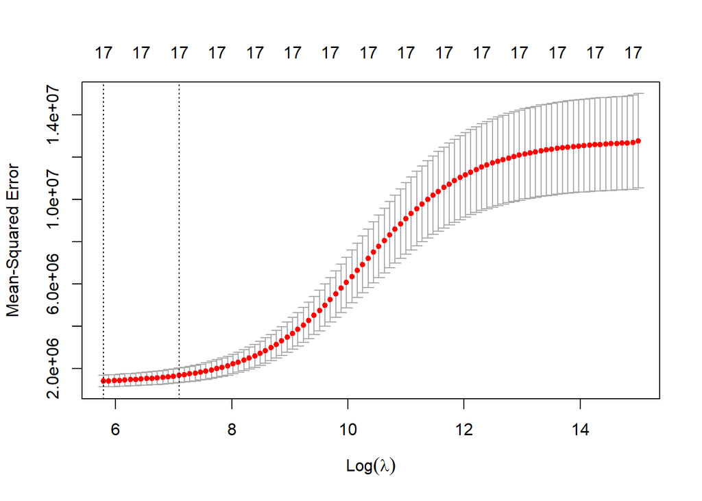

```r
#Matrix X and Vector Y for Training and Test Set
Training.x <- model.matrix(Apps ~ ., data = College_Training)[, -1]
Training.y <- College_Training$Apps

Test.x <- model.matrix(Apps ~ ., data = College_Test)[, -1]
Test.y <- College_Test$Apps

#Using Cross Validation to Choose the Tuning Parameter
set.seed(1234)
CV <- cv.glmnet(Training.x, Training.y, alpha = 0)
plot(CV)
```

```r
#Create Training Model using Best Lambda
best_lambda <- CV$lambda.min
Training_Model <- glmnet(Training.x, Training.y, alpha = 0, lambda = best_lambda)
Training_Model$beta
```

```
## 17 x 1 sparse Matrix of class "dgCMatrix"
##                        s0
## PrivateYes  -820.77910583
## Accept         0.72708563
## Enroll         0.71185405
## Top10perc     30.03161567
## Top25perc     -3.72841808
## F.Undergrad    0.11492687
## P.Undergrad   -0.07369275
## Outstate       0.01872254
## Room.Board     0.21599384
## Books          0.04382755
## Personal      -0.04265103
## PhD           -3.88212060
## Terminal      -9.15683345
## S.F.Ratio     21.53238072
## perc.alumni  -14.38102102
## Expend         0.09012555
## Grad.Rate     11.75690525
```

```r
#Fitting Model on Test Set
Test_Model <- predict(Training_Model, s = best_lambda, newx = Test.x)

#Mean Square Error
MSE <- mean((Test_Model - Test.y)^2)
MSE
```

```
## [1] 2269725
```

**Test Error is 2269725.**

4. Fit a lasso model on the training set, with $\lambda$ chosen by cross-validation. Report the test error obtained, along with the number of non-zero coefficient estimates.

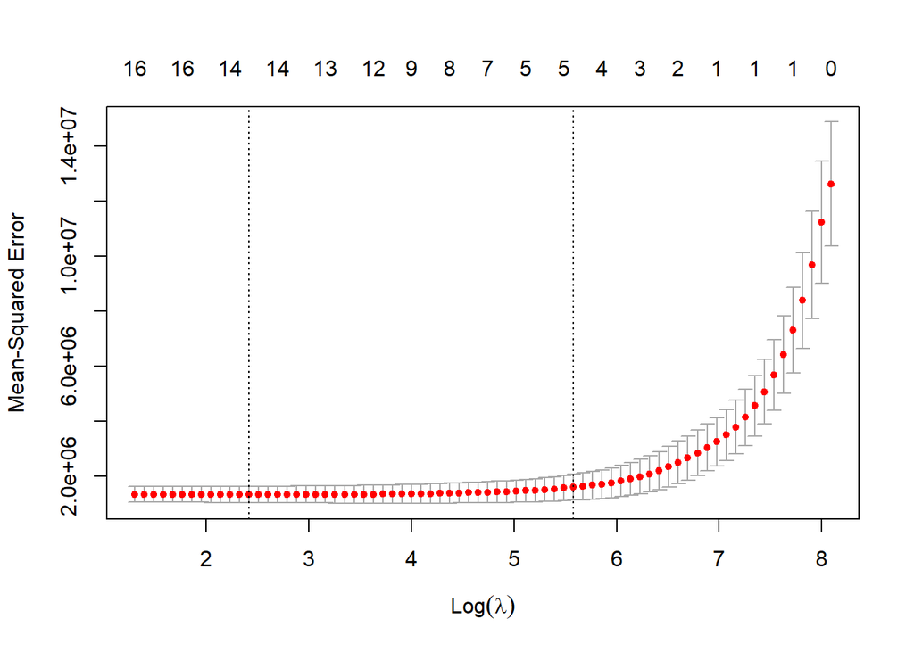

```r
##Using Cross Validation to Choose the Tuning Parameter
set.seed(1234)
CV1 <- cv.glmnet(Training.x, Training.y, alpha = 1)
plot(CV1)
```

```r
#Create Training Model using Best Lambda
best_Lambda1 <- CV1$lambda.min
Training_Model1 <- glmnet(Training.x, Training.y, alpha = 1, lambda = best_Lambda1)
Training_Model1$beta
```

```
## 17 x 1 sparse Matrix of class "dgCMatrix"
##                        s0
## PrivateYes  -903.52504086
## Accept         1.20257421
## Enroll         .
## Top10perc     45.02938926
## Top25perc    -13.44145384
## F.Undergrad    0.03222560
## P.Undergrad   -0.02187848
## Outstate      -0.01583636
## Room.Board     0.15577567
## Books          .
## Personal       .
## PhD           -6.87246757
## Terminal      -8.00113307
## S.F.Ratio     23.08152007
## perc.alumni   -7.82603852
## Expend         0.09262137
## Grad.Rate     10.53657851
```

```r
#Fitting Model on Test Set
Test_Model1 <- predict(Training_Model1, s = best_lambda, newx = Test.x)

#Mean Square Error
MSE <- mean((Test_Model1 - Test.y)^2)
MSE
```

```
## [1] 1346660
```

5. Fit a PCR model on the training set, with $M$ chosen by cross-validation. Report the test error obtained, along with the value of $M$ selected by cross-validation.

```r
library(pls, quietly = TRUE)
```

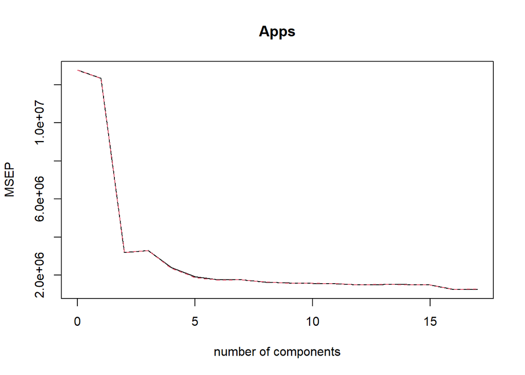

```r
pcr.fit <- pcr(Apps ~ . , data = College_Training, scale = TRUE, validation = "CV")
validationplot(pcr.fit, val.type="MSEP")
```

```r
pcr.pred <-  predict(pcr.fit, College_Test, ncomp = 10)
mean((College_Test[, "Apps"]- pcr.pred)^2)
```

```
## [1] 2888749
```

**Test Error is 2888749.**

6. Comment on the results obtained. How accurately can we predict the number of college applications received? Is there much difference among the test errors resulting from these five approaches?

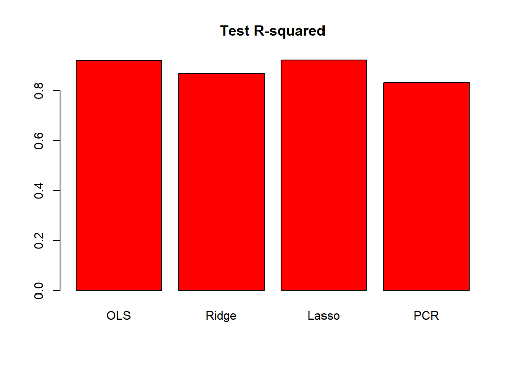

```r
test.avg <-  mean(College_Test[, "Apps"])

lm.test.r2 <-  1 - mean((College_Test[, "Apps"] - Predict)^2) /
  mean((College_Test[, "Apps"] - test.avg)^2)

ridge.test.r2 <-  1 - mean((College_Test[, "Apps"] - Test_Model)^2)/
  mean((College_Test[, "Apps"] - test.avg)^2)

lasso.test.r2 <-  1 - mean((College_Test[, "Apps"] - Test_Model1)^2) /
  mean((College_Test[, "Apps"] - test.avg)^2)

pcr.test.r2 <-  1 - mean((College_Test[, "Apps"] - pcr.pred)^2) /
  mean((College_Test[, "Apps"] - test.avg)^2)

barplot(c(lm.test.r2, ridge.test.r2, lasso.test.r2, pcr.test.r2),
        col = "red", names.arg = c("OLS", "Ridge", "Lasso", "PCR"),
        main = "Test R-squared")
```

**The plot shows that test $R^2$ for all models except PCR are around 0.9. PCR has a smaller test $R^2$. Out of the 4 models, all models except PCR predict college applications with high accuracy.**

## Exercise 7.3 (Optional)

We will now try to predict per capita crime rate in the `Boston` data set.

```r
data("Boston", package = "MASS")
```

1. Try out some of the regression methods we explored, such as the lasso, ridge regression, and PCR. Present and discuss results for the approaches that you consider.

```r
library(glmnet, quietly = TRUE)
library(pls, quietly = TRUE)
library(knitr, quietly = TRUE)

#Splitting Training and Test Set
set.seed(1234)

split.sample = sample.split(Boston, SplitRatio = 0.7)
training <- subset(Boston, split.sample == TRUE)
test <- subset(Boston, split.sample == FALSE)

#Matrix X and Vector Y for Training and Test Set
x.train <- model.matrix(crim ~ ., data = training)[, -1]
y.train <- training$crim

x.test <- model.matrix(crim ~ ., data = test)[, -1]
y.test <- test$crim

#Ridge Regression
set.seed(1234)

cv.ridge <- cv.glmnet(x.train, y.train, alpha = 0)
lambda.ridge <- cv.ridge$lambda.min
ridge.train <- glmnet(x.train, y.train, alpha = 0, lambda = lambda.ridge)

ridge.test <- predict(ridge.train, s = lambda.ridge, newx = x.test)
ridge.mse <- mean((ridge.test - y.test) ^ 2)

#Lasso Regression
set.seed(1234)

cv.lasso <- cv.glmnet(x.train, y.train, alpha = 1)
lambda.lasso <- cv.lasso$lambda.min
lasso.train <- glmnet(x.train, y.train, alpha = 1, lambda = lambda.lasso)

lasso.test <- predict(lasso.train, s = lambda.lasso, newx = x.test)
lasso.mse <- mean((lasso.test - y.test) ^ 2)

#pcr
set.seed(1234)
pcr_fit <- pcr(crim ~ . , data = training, scale = TRUE, validation = "CV")
pcr_pred <-  predict(pcr_fit, test, ncomp = 10)
pcr.mse <- mean((test[, "crim"]- pcr_pred)^2)

#Comparison table
mse.table <- cbind(ridge.mse, lasso.mse, pcr.mse)
rownames(mse.table) <- "MSE"
colnames(mse.table) <- c("Ridge", "Lasso", "PCR")
kable(mse.table)
```

|  | Ridge | Lasso | PCR |
| --- | --- | --- | --- |
| MSE | 38.92876 | 38.96594 | 40.43807 |

**Ridge regression has the lowest MSE, implying that ridge regression provides the best performance in terms of prediction accuracy for the Boston dataset.**

2. Propose a model (or set of models) that seem to perform well on this data set, and justify your answer. Make sure that you are evaluating model performance using validation set error, cross-validation, or some other reasonable alternative, as opposed to using training error.

**An elastic net regression model is proposed. Elastic net regression is a linear regression model that combines the penalties of both L1 (Lasso) and L2 (Ridge) regularization methods. It is a type of regularized regression model that is used to prevent overfitting and improve the prediction performance of the model.The tradeoffs between the L1 and L2 penalties are controlled by $\alpha$. When $\alpha$ is set to a value $0<\alpha<1$, the model uses a combination of L1 and L2 penalties, thus the elastic net model.**

```r
set.seed(1234)

cv.elastic <- cv.glmnet(x.train, y.train, alpha = 0.5)
lambda.elastic <- cv.elastic$lambda.min
elastic.train <- glmnet(x.train, y.train, alpha = 0.5, lambda = lambda.elastic)

elastic.test <- predict(elastic.train, s = lambda.elastic, newx = x.test)
elastic.mse <- mean((elastic.test - y.test) ^ 2)

mse.table1 <- cbind(ridge.mse, lasso.mse, elastic.mse)
rownames(mse.table1) <- "MSE"
colnames(mse.table1) <- c("Ridge", "Lasso", "Elastic")
kable(mse.table1)
```

|  | Ridge | Lasso | Elastic |
| --- | --- | --- | --- |
| MSE | 38.92876 | 38.96594 | 38.97872 |

**As shown in the table above, Ridge regression still has the lowest MSE value, making it a more appropriate model compare to Elastic Net and Lasso. This could be due to the fact that the L1 penalty in elastic net regression, which encourages sparsity and feature selection, might be too strong, leading to some relevant features being excluded from the model.**

3. Does your chosen model involve all of the features in the data set? Why or why not?